# lab2_wenhui

wenhui li

9/19/2021

# 1

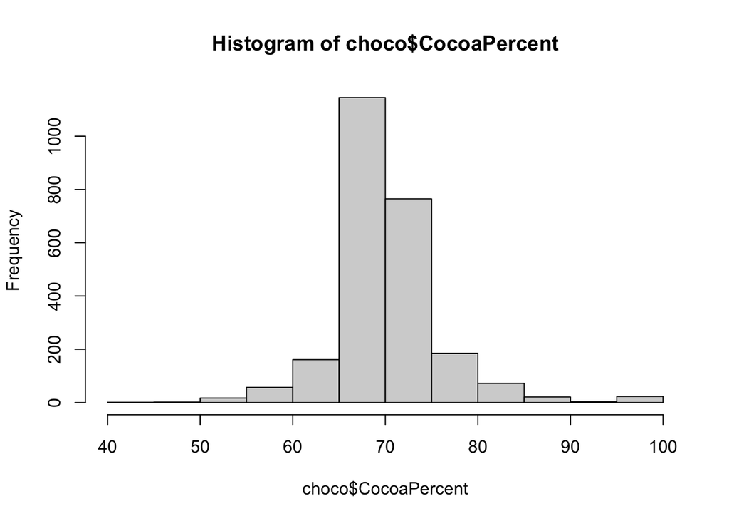

```r
library(classdata)
data(choco)
hist(choco$CocoaPercent)
```

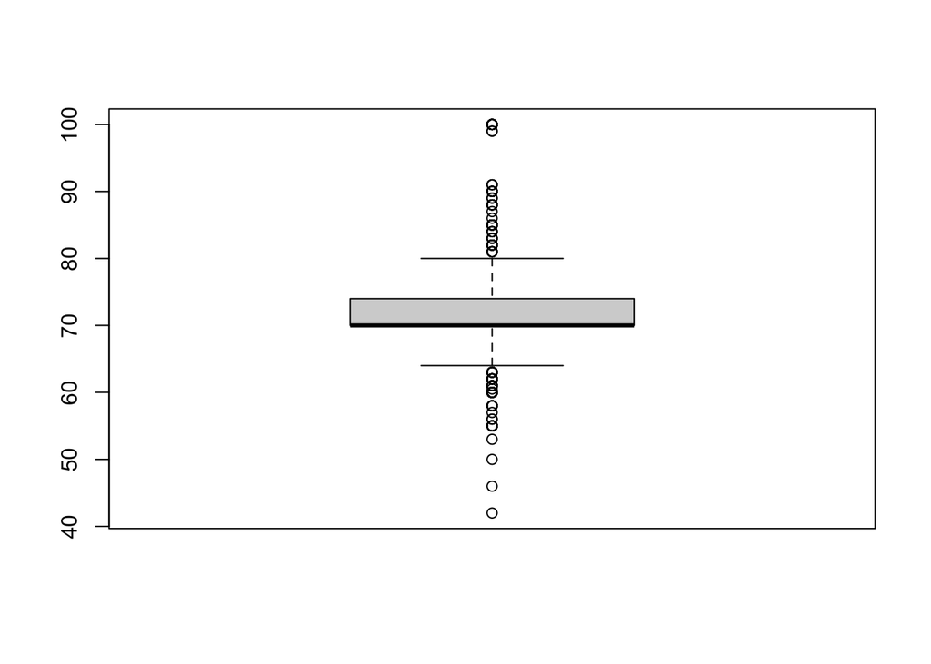

```r
boxplot(choco$CocoaPercent)
```

From the histogram plot and the boxplot, I would say most of cocoapercent is around 65-75 percent. There are outliers at 95-100 percent and 40-50 percent.

# 2

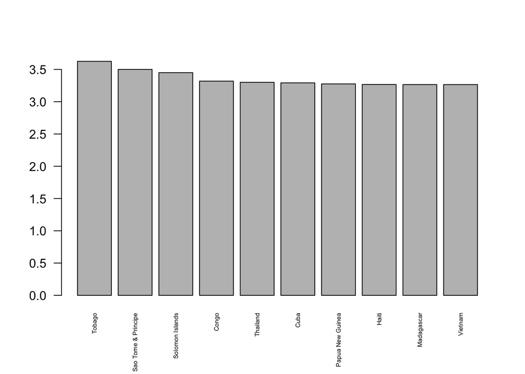

```r
meanrating <- tapply(choco$Rating,choco$CountryBeanOrigin,mean)
top10 <- sort(meanrating, decreasing = TRUE)[1:10]
barplot(top10,las = 2, cex.names = 0.5)
```

I take the top10 countries to make the graph readable. The result is showed above.

# 3

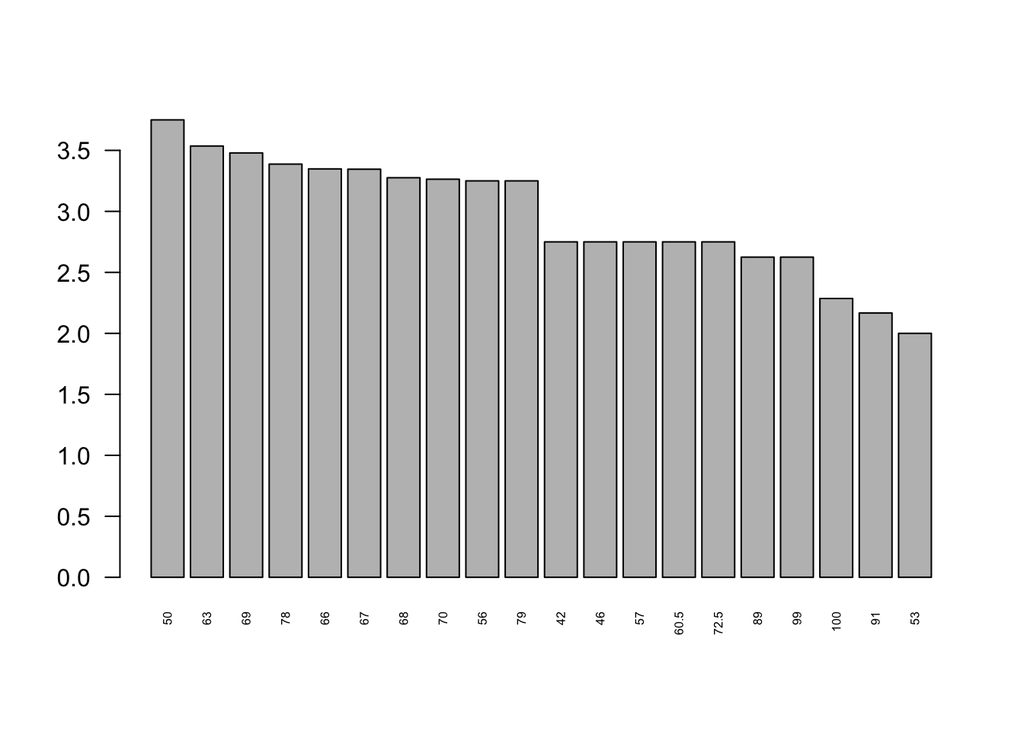

```r
relation <- tapply(choco$Rating,choco$CocoaPercent, mean)
high10 <- sort(relation, decreasing = TRUE)[1:10]
low10 <- sort(relation)[1:10]
relationhl<- c(low10,high10)
final<- sort(relationhl,decreasing = TRUE)
barplot(final, las=2, cex.names = 0.5)
```

I took the mean Rating as the numerical summaries. To make the graph readable, I took 10 high values and 10 low values. From the barplot I would say the best cocoa percent is around 50-80 percent.

# 4

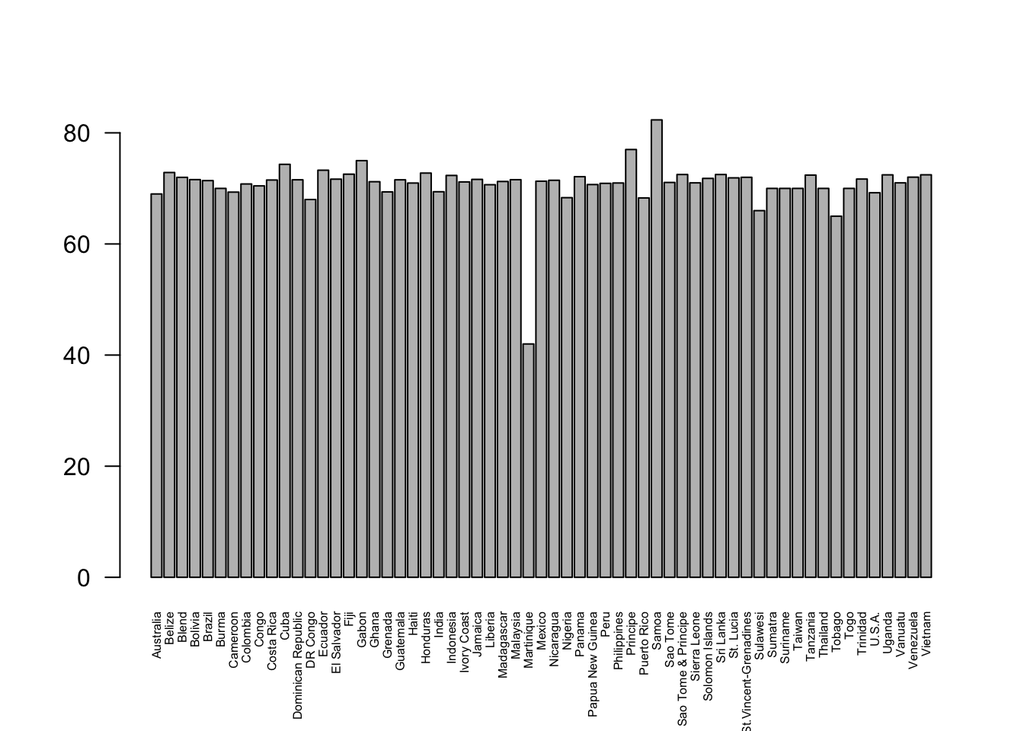

```r
origins <- tapply(choco$CocoaPercent,choco$CountryBeanOrigin, mean)
barplot(origins,las = 2, cex.names = 0.5)
```

I used the mean of cocoa percent to define the flavor of chocolate by different bean origins. I can see from the barplot that most of places produced about 60-80 cocoapercent chocolate. This is also consistent with the result I got from question#3. However, Martinque’s chocolates have 40 percents of cocoa on mean which is the different one.

# 5

## Question1: Which year’s chocolates have the best rating result?

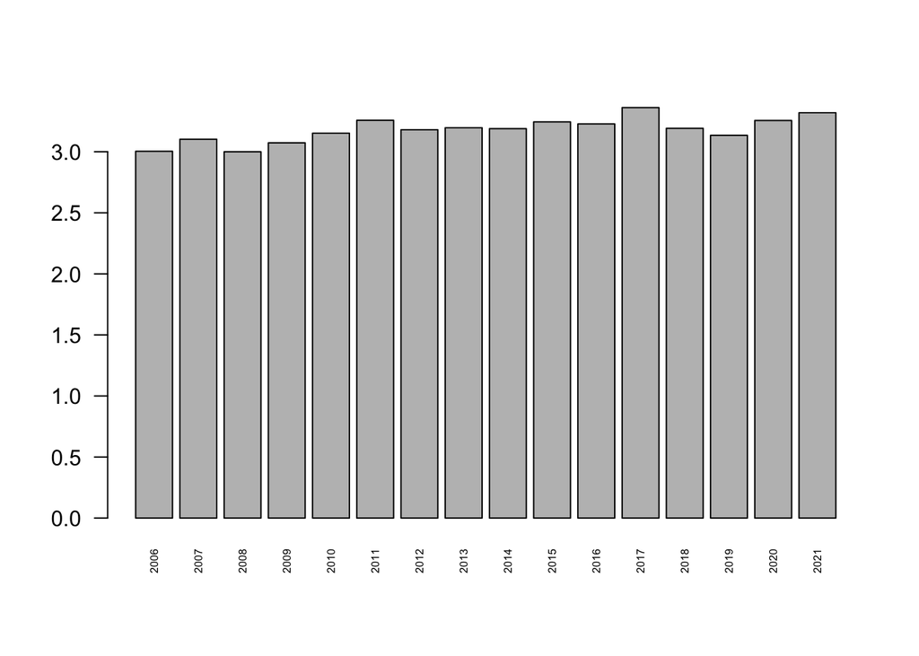

```r
years <- tapply(choco$Rating,choco$ReviewDate, mean)
barplot(years,las = 2, cex.names = 0.5)
```

I also take the mean value of the rating compare with years. From the barplot, I would say products reviewd in 2017 has the highest rating value.

## Questin2: How is the rating in 2019?

```r
rating19 <- choco[choco$ReviewDate == 2019,'Rating']
print(mean(rating19))
```

```
## [1] 3.134715
```

I used the mean rating of chocolate reviewd in 2019 to present the result which is printed above.